# Project (Assignment 3): Unsupervised Learning (E-Commerce Orders)

This notebook is your working template for **Assignment 3**.

**Note:** This assessment comprises two parts: question-guided processing/modeling (Unsupervised learning) and free-form exploration.

**Total Marks: 20**

You will:

- Continue working with the expanded dataset from Assignment 1
- Perform **clustering** to identify similar order types
- Apply **market basket analysis** (association rule mining)
- Write up findings throughout the notebook
- Publish your analysis as a github.io page

Work **top-to-bottom**. Complete each task in order before moving on.

## Submitted by

Group number on Canvas: 3

| Student ID (AxxxxxxxZ) | NUSNet ID (exxxxxxx) | Name (as it appears on Canvas) |
| --- | --- | --- |
| A0331401B | E1582257 | CHEN SITONG |
| A0319073E | E1520933 | LIANG MENGYING |
| A0326625A | E1538456 | LIN ZHANGXIN |
| A0328710J | E1553037 | SHI YANCHUN |

## Setup

Run the cell below to import the required Python packages.

```python
import warnings
warnings.filterwarnings('ignore')

import pandas as pd
import numpy as np
import matplotlib.pyplot as plt
import seaborn as sns

from sklearn.model_selection import train_test_split
from sklearn.preprocessing import StandardScaler
from sklearn.cluster import KMeans

from mlxtend.preprocessing import TransactionEncoder
from mlxtend.frequent_patterns import apriori, association_rules

plt.style.use('seaborn-v0_8')
```

## Load Your Cleaned Dataset from Assignment 1

Load the cleaned and expanded dataset you created in Assignment 1 (and potentially modified in Assignment 2).

```python
# ANSWER: Load your cleaned dataset
from google.colab import drive
drive.mount('/content/drive')

DATA_PATH = "/content/drive/MyDrive/IT5100F/ecommerce_orders_cleaned.csv"
df = pd.read_csv(DATA_PATH)

print(f"Dataset shape: {df.shape}")
df.head()
```

```
Dataset shape: (46287, 17)
```

|  | order_id | order_status | order_purchase_hour | order_purchase_dayofweek | order_purchase_month | order_total_value | num_items | num_unique_products | num_unique_sellers | total_item_price | avg_item_price | total_freight_value | top_product_category | customer_state | payment_type | order_value_per_item | order_size_category |
| --- | --- | --- | --- | --- | --- | --- | --- | --- | --- | --- | --- | --- | --- | --- | --- | --- | --- |
| 0 | sdv-id-whzjUX | shipped | 10 | 4 | 4 | 744.312535 | 1 | 1 | 1 | 352.420029 | 369.966521 | 68.790159 | construction_tools_construction | Massachusetts | voucher | 352.420029 | Small |
| 1 | sdv-id-dbopoJ | delivered | 19 | 2 | 3 | 1556.667902 | 1 | 1 | 1 | 289.242639 | 1354.621410 | 15.394619 | health_beauty | Vermont | credit_card | 289.242639 | Small |
| 2 | sdv-id-FSEOvM | delivered | 15 | 4 | 8 | 62.060506 | 1 | 1 | 1 | 26.893468 | 48.485654 | 18.751282 | luggage_accessories | South Carolina | debit_card | 26.893468 | Small |
| 3 | sdv-id-bQcBUR | delivered | 21 | 0 | 8 | 73.873470 | 1 | 1 | 1 | 37.790896 | 75.704909 | 8.670875 | computers_accessories | Kentucky | credit_card | 37.790896 | Small |
| 4 | sdv-id-MPxIXB | delivered | 13 | 5 | 5 | 361.961537 | 3 | 3 | 3 | 169.528323 | 50.132979 | 34.731146 | pet_shop | Missouri | voucher | 56.509441 | Medium |

## Task: Unsupervised Learning

### Objective

In this task, you will work on unsupervised learning and support your analysis with visualization. Perform clustering to identify **similar orders** and generate **order type recommendations** based on their characteristics. An order type cluster represents a group of orders with similar purchasing patterns, value structures, and composition.

### 1: Data Preprocessing for Unsupervised Learning [1 Mark]

Goal: Create DataFrames that contain one row per order with features suitable for both clustering and association mining.

#### 1.1 Create `all_orders_df` (one row per order)

Create a new DataFrame called `all_orders_df` with the following columns:

Identifier:

- `order_id` — Unique identifier of the order
- `basket_size` — Monetary value of the order (from `order_total_value`)
- `basket_qty` — Number of items in the order (from `num_items`)
- `freight_ratio` — Proportion of the order value that is freight (computed as `total_freight_value / order_total_value`)
- `product_diversity` — How varied the basket is in terms of product types (computed as `num_unique_products / num_items`)
- `top_product_category` — The dominant product category in the order
- `payment_type` — The payment method used
- `order_size_category` — The order size category (Small/Medium/Large)

Notes:

- `all_orders_df` must have exactly one row per `order_id`.
- No missing values should remain in these columns after preprocessing (apply reasonable handling if needed).
- Handle potential division issues appropriately (e.g., orders with zero values).
- Display the first 10 rows of `all_orders_df`, its shape, and data types.

```python
# 1.1 ANSWER: Create all_orders_df
all_orders_df = df[["order_id"]].copy()

all_orders_df["basket_size"] = df["order_total_value"]
all_orders_df["basket_qty"]  = df["num_items"]

denom_value = df["order_total_value"].replace(0, np.nan)
denom_items = df["num_items"].replace(0, np.nan)

all_orders_df["freight_ratio"] = df["total_freight_value"] / denom_value
all_orders_df["product_diversity"] = df["num_unique_products"] / denom_items

all_orders_df["top_product_category"] = df["top_product_category"]
all_orders_df["payment_type"] = df["payment_type"]
all_orders_df["order_size_category"] = df["order_size_category"]

# if any NaN caused by zero division, fill with 0
all_orders_df[["freight_ratio", "product_diversity"]] = all_orders_df[["freight_ratio", "product_diversity"]].fillna(0)

all_orders_df.head(10)
```

|  | order_id | basket_size | basket_qty | freight_ratio | product_diversity | top_product_category | payment_type | order_size_category |
| --- | --- | --- | --- | --- | --- | --- | --- | --- |
| 0 | sdv-id-whzjUX | 744.312535 | 1 | 0.092421 | 1.000000 | construction_tools_construction | voucher | Small |
| 1 | sdv-id-dbopoJ | 1556.667902 | 1 | 0.009889 | 1.000000 | health_beauty | credit_card | Small |
| 2 | sdv-id-FSEOvM | 62.060506 | 1 | 0.302145 | 1.000000 | luggage_accessories | debit_card | Small |
| 3 | sdv-id-bQcBUR | 73.873470 | 1 | 0.117375 | 1.000000 | computers_accessories | credit_card | Small |
| 4 | sdv-id-MPxIXB | 361.961537 | 3 | 0.095953 | 1.000000 | pet_shop | voucher | Medium |
| 5 | sdv-id-ySodbB | 867.750230 | 7 | 0.204442 | 0.857143 | sports_leisure | voucher | Large |
| 6 | sdv-id-wdwBrk | 55.965822 | 2 | 0.285101 | 0.500000 | toys | points | Small |
| 7 | sdv-id-maBYtk | 170.295452 | 3 | 0.089290 | 1.000000 | computers_accessories | voucher | Medium |
| 8 | sdv-id-oodUXj | 83.065603 | 1 | 0.236471 | 1.000000 | furniture_decor | voucher | Small |
| 9 | sdv-id-zroJIL | 98.250248 | 1 | 0.369709 | 1.000000 | fashion_bags_accessories | points | Small |

#### 1.2 Create `orders_analysis_df`

- Use `train_test_split` from sklearn to split the data in `all_orders_df`.
- Set `test_size=0.3` (keep 30% of data for analysis) and `random_state=37` for reproducibility.
- Assign the **test set** to the variable `orders_analysis_df`.

Display the shape of `orders_analysis_df` and show its first 10 rows.

```python
# 1.2 ANSWER: Create orders_analysis_df using train_test_split
# Define the numerical features for clustering
num_cols = ['basket_size', 'basket_qty', 'freight_ratio', 'product_diversity']

_, orders_analysis_df = train_test_split(
    all_orders_df,
    test_size=0.3,
    random_state=37
)

print(f"Shape of orders_analysis_df: {orders_analysis_df.shape}")
print("\nData Types:")
print(orders_analysis_df.dtypes)
display(orders_analysis_df.head(10))
```

```
Shape of orders_analysis_df: (13887, 8)

Data Types:
order_id                 object
basket_size             float64
basket_qty                int64
freight_ratio           float64
product_diversity       float64
top_product_category     object
payment_type             object
order_size_category      object
dtype: object
```

|  | order_id | basket_size | basket_qty | freight_ratio | product_diversity | top_product_category | payment_type | order_size_category |
| --- | --- | --- | --- | --- | --- | --- | --- | --- |
| 1882 | sdv-id-ISddRn | 132.611695 | 1 | 0.126285 | 1.000000 | christmas_supplies | voucher | Small |
| 40995 | sdv-id-GmlErp | 730.510053 | 6 | 0.075288 | 0.666667 | furniture_decor | credit_card | Large |
| 40104 | sdv-id-BWpket | 632.486142 | 1 | 0.051262 | 1.000000 | bed_bath_table | credit_card | Small |
| 25808 | sdv-id-krmbPT | 47.102393 | 1 | 0.248932 | 1.000000 | telephony | credit_card | Small |
| 23294 | sdv-id-vhfMmG | 133.285008 | 1 | 0.135860 | 1.000000 | health_beauty | debit_card | Small |
| 7160 | sdv-id-kcTYfM | 403.696187 | 2 | 0.079065 | 0.500000 | auto | credit_card | Small |
| 7180 | sdv-id-tFFFCg | 211.465148 | 2 | 0.162263 | 1.000000 | furniture_decor | voucher | Small |
| 20801 | sdv-id-KgDKAA | 57.520738 | 1 | 0.228879 | 1.000000 | bed_bath_table | credit_card | Small |
| 19879 | sdv-id-cfCjEB | 576.212699 | 3 | 0.056350 | 0.666667 | bed_bath_table | credit_card | Medium |
| 39874 | sdv-id-uxRZME | 141.772602 | 2 | 0.200719 | 1.000000 | fashion_bags_accessories | credit_card | Small |

### 2: Determine the Optimal Number of Clusters [3 Marks]

#### 2.1 Run K-Means for Different Cluster Numbers

- Use **only the four numerical features** from `orders_analysis_df` (`basket_size`, `basket_qty`, `freight_ratio`, `product_diversity`) for clustering.
- Run K-means clustering from **k = 3 to 9** clusters.
- Important: First scale the numerical features using `StandardScaler` before fitting K-means.
- In each run, calculate the **inertia** of the cluster and store the values for each k (3 to 9) in a list or table.

Inertia is a measure of how tightly packed the clusters are. It is the sum of squared distances between each point and its assigned cluster center (centroid). Lower inertia indicates that the clusters are more compact, and the points are closer to their centroids, suggesting better clustering.

```python
# 2.1 ANSWER: Run K-means for k=3 to 9 and calculate inertia
from sklearn.cluster import KMeans
from sklearn.preprocessing import StandardScaler

num_features = ['basket_size', 'basket_qty', 'freight_ratio', 'product_diversity']

scaler_analysis = StandardScaler()
X_analysis_scaled = scaler_analysis.fit_transform(orders_analysis_df[num_features])

k_values = range(3, 10)
inertias = []

for k in k_values:
    kmeans = KMeans(n_clusters=k, random_state=37, n_init=10)
    kmeans.fit(X_analysis_scaled)
    inertia_val = kmeans.inertia_
    inertias.append(inertia_val)
    print(f"For k = {k}, Inertia = {inertia_val:.2f}")

print("-" * 30)

inertia_df = pd.DataFrame({'Number of Clusters (k)': k_values, 'Inertia': inertias})
display(inertia_df)
```

```
For k = 3, Inertia = 28884.29
For k = 4, Inertia = 21464.39
For k = 5, Inertia = 17303.04
For k = 6, Inertia = 15013.97
For k = 7, Inertia = 13219.44
For k = 8, Inertia = 11762.79
For k = 9, Inertia = 10516.16
------------------------------
```

|  | Number of Clusters (k) | Inertia |
| --- | --- | --- |
| 0 | 3 | 28884.287460 |
| 1 | 4 | 21464.393895 |
| 2 | 5 | 17303.035640 |
| 3 | 6 | 15013.968444 |
| 4 | 7 | 13219.438102 |
| 5 | 8 | 11762.794068 |
| 6 | 9 | 10516.159393 |

#### 2.2 Elbow Method for Optimal Clusters

- Plot the **inertia** (y-axis) against the **number of clusters** (x-axis) to identify the optimal number of clusters using the **Elbow method**.

The Elbow Method helps in selecting the number of clusters by identifying where the inertia starts to decrease more slowly.

- Based on the Elbow plot, **choose the optimal number of clusters** and state your choice clearly.

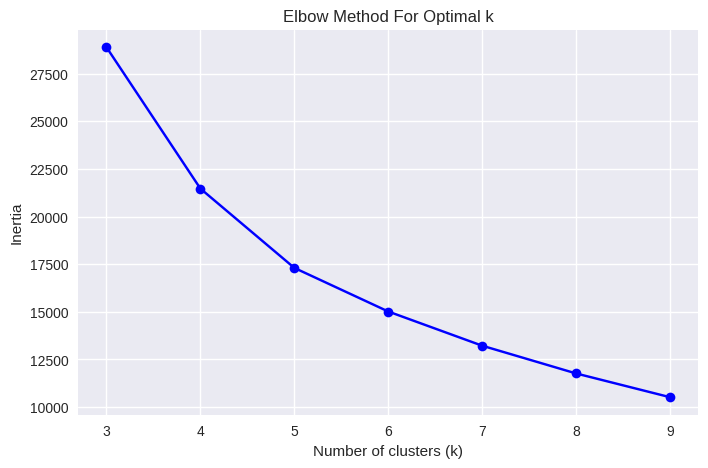

```python
# 2.2 ANSWER: Create Elbow plot
plt.figure(figsize=(8, 5))
plt.plot(k_values, inertias, marker='o', linestyle='-', color='b')
plt.title('Elbow Method For Optimal k')
plt.xlabel('Number of clusters (k)')
plt.ylabel('Inertia')
plt.xticks(k_values)
plt.grid(True)
plt.show()
```

Based on the Elbow plot, the rate of inertia decrease begins to slow down significantly at **k=5**. Therefore, I choose 5 as the optimal number of clusters.

### 3: Cluster Analysis and Visualization [3 Marks]

#### 3.1 Identify the Cluster Number for Each Order

- Create a K-means model using the four numerical features from `all_orders_df` and the optimal number of clusters identified in Task 2.
- Fit the model on the scaled numerical features.
- Use the fitted model to assign a cluster number to each order and add a new column called `cluster` to `all_orders_df`.
- Show the first 10 rows of `all_orders_df` to verify cluster assignment.

```python
# 3.1 ANSWER: Fit K-means with optimal k and assign clusters
optimal_k = 5

scaler_full = StandardScaler()
X_full_scaled = scaler_full.fit_transform(all_orders_df[num_features])

final_kmeans = KMeans(n_clusters=optimal_k, random_state=37, n_init=10)
final_kmeans.fit(X_full_scaled)

all_orders_df['cluster'] = final_kmeans.labels_
display(all_orders_df.head(10))
```

|  | order_id | basket_size | basket_qty | freight_ratio | product_diversity | top_product_category | payment_type | order_size_category | cluster |
| --- | --- | --- | --- | --- | --- | --- | --- | --- | --- |
| 0 | sdv-id-whzjUX | 744.312535 | 1 | 0.092421 | 1.000000 | construction_tools_construction | voucher | Small | 0 |
| 1 | sdv-id-dbopoJ | 1556.667902 | 1 | 0.009889 | 1.000000 | health_beauty | credit_card | Small | 4 |
| 2 | sdv-id-FSEOvM | 62.060506 | 1 | 0.302145 | 1.000000 | luggage_accessories | debit_card | Small | 3 |
| 3 | sdv-id-bQcBUR | 73.873470 | 1 | 0.117375 | 1.000000 | computers_accessories | credit_card | Small | 0 |
| 4 | sdv-id-MPxIXB | 361.961537 | 3 | 0.095953 | 1.000000 | pet_shop | voucher | Medium | 0 |
| 5 | sdv-id-ySodbB | 867.750230 | 7 | 0.204442 | 0.857143 | sports_leisure | voucher | Large | 2 |
| 6 | sdv-id-wdwBrk | 55.965822 | 2 | 0.285101 | 0.500000 | toys | points | Small | 1 |
| 7 | sdv-id-maBYtk | 170.295452 | 3 | 0.089290 | 1.000000 | computers_accessories | voucher | Medium | 0 |
| 8 | sdv-id-oodUXj | 83.065603 | 1 | 0.236471 | 1.000000 | furniture_decor | voucher | Small | 3 |
| 9 | sdv-id-zroJIL | 98.250248 | 1 | 0.369709 | 1.000000 | fashion_bags_accessories | points | Small | 3 |

#### 3.2 Visualize the Clusters

Create two visualizations to understand your clusters:

- **Visualization 1: Cluster Profile Heatmap**
  - Visualize the cluster profiles using a heatmap to understand the average characteristics of each segment.
  - Step 1: Compute the mean of the four numerical features (`basket_size`, `basket_qty`, `freight_ratio`, `product_diversity`) for each cluster.
  - Step 2: Scale these means (e.g., using `StandardScaler` to calculate Z-scores) so that different units (price vs. count) can be compared directly.
  - Step 3: Plot the scaled means as a heatmap:
    - X-axis: Cluster number
    - Y-axis: Feature name
    - Color: Use a diverging colormap (e.g., `RdBu_r`) to distinguish features that are above average (positive Z-score) from those that are below average (negative Z-score)
    - Annotation: Display the Z-score values in each cell
  - Add a clear title.
- **Visualization 2: Cluster Size Distribution**
  - Create a bar chart showing the number of orders in each cluster.
    - X-axis: Cluster number (0, 1, 2, ...)
    - Y-axis: Count of orders
    - This helps you understand if clusters are balanced or if some clusters dominate.
  - Add a title and axis labels.

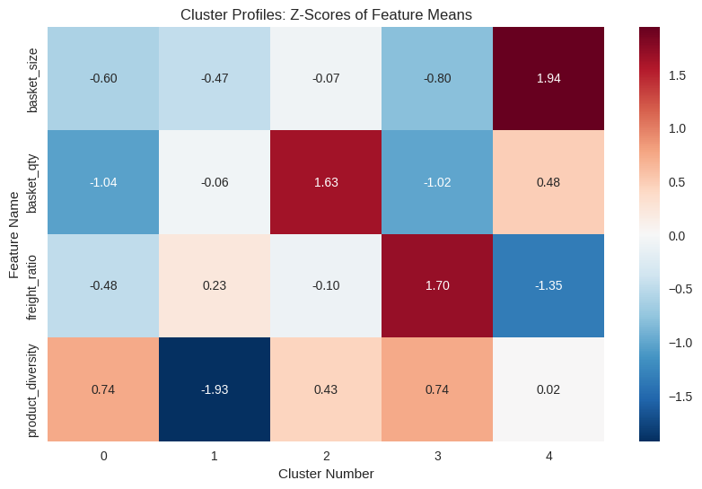

```python
# 3.2 ANSWER: Visualization 1 - Cluster profile heatmap
cluster_means = all_orders_df.groupby('cluster')[num_features].mean()

scaler_heatmap = StandardScaler()
scaled_means = scaler_heatmap.fit_transform(cluster_means)
scaled_means_df = pd.DataFrame(scaled_means, index=cluster_means.index, columns=cluster_means.columns)

plt.figure(figsize=(10, 6))
sns.heatmap(scaled_means_df.T, cmap='RdBu_r', annot=True, fmt=".2f", center=0)
plt.title('Cluster Profiles: Z-Scores of Feature Means')
plt.xlabel('Cluster Number')
plt.ylabel('Feature Name')
plt.show()
```

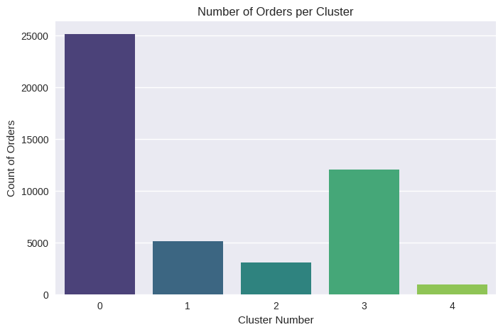

```python
# 3.2 ANSWER: Visualization 2 - Cluster size distribution
plt.figure(figsize=(8, 5))
sns.countplot(data=all_orders_df, x='cluster', palette='viridis')
plt.title('Number of Orders per Cluster')
plt.xlabel('Cluster Number')
plt.ylabel('Count of Orders')
plt.show()
```

**Briefly comment (2-3 sentences) on:**

- How well separated do the clusters appear based on the heatmap?
- Which features seem to have the most significant impact on defining the clusters? Why might this be the case?
- Based on the visualizations that you have generated, comment on the nature of the clusters and what it implies for an e-commerce business

**3.2 ANSWER:**

- Looking at the heatmap, the clusters are actually quite well-separated, with clear high and low Z-scores across the different groups.
- The features `basket_size` and `basket_qty` seem to play the biggest role in shaping these clusters. They easily separate the large, high-value bulk orders from the small, single-item ones.
- From a business perspective, this segmentation is really useful. The company can use these customer groups to run targeted marketing campaigns or adjust their shipping plans based on how people actually shop.

### 4: Market Basket Analysis (Association Rule Mining) [8 Marks]

#### 4.1 Context: What is Market Basket Analysis?

Market Basket Analysis is an unsupervised learning technique that identifies which products, categories, or attributes are frequently observed together. In e-commerce, this helps answer questions such as:

- "Which payment methods are preferred for which product categories?"
- "Do certain order sizes correlate with specific product types?"
- "What are the multi-dimensional patterns across category, payment, and order size?"

Association rules are commonly described using three key metrics:

- **Support**: How frequently a pattern occurs (0-1 scale)
- **Confidence**: Likelihood of the consequent given the antecedent (0-1 scale)
- **Lift**: How much more likely the rule is compared to random chance (> 1 indicates a positive association)

The Apriori algorithm discovers frequent itemsets and then generates association rules from them.

In this task, you will perform Market Basket Analysis using the categorical features from `all_orders_df` to discover multi-dimensional associations between product category, payment type, and order size category.

#### 4.2 Prepare Transaction Data [1 Mark]

Convert each order in `all_orders_df` into a simple "basket" representation.

Create a Python list called `transactions`, where each element represents one order and contains exactly three string items constructed from that order:

- `cat_{top_product_category}` (e.g., `cat_electronics`, `cat_furniture_decor`)
- `pay_{payment_type}` (e.g., `pay_credit_card`, `pay_boleto`)
- `size_{order_size_category}` (e.g., `size_Small`, `size_Large`)

After constructing `transactions`, display the first 5 transactions to verify the format.

```python
# 4.2 ANSWER: Create transaction list

transactions = []

for _, row in all_orders_df.iterrows():
    basket = [
        f"cat_{row['top_product_category']}",
        f"pay_{row['payment_type']}",
        f"size_{row['order_size_category']}"
    ]
    transactions.append(basket)

# Display first 5 transactions
transactions[:5]
```

```
[['cat_construction_tools_construction', 'pay_voucher', 'size_Small'],
 ['cat_health_beauty', 'pay_credit_card', 'size_Small'],
 ['cat_luggage_accessories', 'pay_debit_card', 'size_Small'],
 ['cat_computers_accessories', 'pay_credit_card', 'size_Small'],
 ['cat_pet_shop', 'pay_voucher', 'size_Medium']]
```

#### 4.3 Encode Transactions and Apply Apriori Algorithm [2 Marks]

Use the `mlxtend` library to discover frequent itemsets and generate association rules.

- Step 1: Encode transactions using `TransactionEncoder` and display the shape of the encoded DataFrame.
- Step 2: Apply `apriori()` with `min_support = 0.01` and `use_colnames = True`, then display the number of frequent itemsets found.
- Step 3: Generate association rules using `association_rules()` with `metric = 'lift'` and `min_threshold = 1.0`, then display the number of rules generated.

```python
# 4.3 ANSWER: Step 1 - Encode transactions
from mlxtend.preprocessing import TransactionEncoder

te = TransactionEncoder()
encoded_df = pd.DataFrame(te.fit_transform(transactions),columns=te.columns_)

print("Shape of encoded DataFrame:", encoded_df.shape)
encoded_df.head()
```

```
Shape of encoded DataFrame: (46287, 79)
```

|  | cat_agro_industry_and_commerce | cat_air_conditioning | cat_art | cat_arts_and_craftmanship | cat_audio | cat_auto | cat_baby | cat_bed_bath_table | cat_books_general_interest | cat_books_imported | ... | cat_toys | cat_watches_gifts | pay_credit_card | pay_debit_card | pay_not_defined | pay_points | pay_voucher | size_Large | size_Medium | size_Small |
| --- | --- | --- | --- | --- | --- | --- | --- | --- | --- | --- | --- | --- | --- | --- | --- | --- | --- | --- | --- | --- | --- |
| 0 | False | False | False | False | False | False | False | False | False | False | ... | False | False | False | False | False | False | True | False | False | True |
| 1 | False | False | False | False | False | False | False | False | False | False | ... | False | False | True | False | False | False | False | False | False | True |
| 2 | False | False | False | False | False | False | False | False | False | False | ... | False | False | False | True | False | False | False | False | False | True |
| 3 | False | False | False | False | False | False | False | False | False | False | ... | False | False | True | False | False | False | False | False | False | True |
| 4 | False | False | False | False | False | False | False | False | False | False | ... | False | False | False | False | False | False | True | False | True | False |

5 rows × 79 columns

```python
# 4.3 ANSWER: Step 2 - Apply Apriori
from mlxtend.frequent_patterns import apriori

frequent_itemsets = apriori(encoded_df,min_support=0.01,use_colnames=True)

# Display number of frequent itemsets
print("Number of frequent itemsets found:", len(frequent_itemsets))

frequent_itemsets.head()
```

```
Number of frequent itemsets found: 102
```

|  | support | itemsets |
| --- | --- | --- |
| 0 | 0.030592 | (cat_auto) |
| 1 | 0.023592 | (cat_baby) |
| 2 | 0.138678 | (cat_bed_bath_table) |
| 3 | 0.073152 | (cat_computers_accessories) |
| 4 | 0.016311 | (cat_consoles_games) |

```python
# 4.3 ANSWER: Step 3 - Generate association rules
from mlxtend.frequent_patterns import association_rules

rules = association_rules(frequent_itemsets,metric="lift",min_threshold=1.0)

# Display number of rules
print("Number of association rules generated:", len(rules))

rules.head()
```

```
Number of association rules generated: 138
```

|  | antecedents | consequents | antecedent support | consequent support | support | confidence | lift | representativity | leverage | conviction | zhangs_metric | jaccard | certainty | kulczynski |
| --- | --- | --- | --- | --- | --- | --- | --- | --- | --- | --- | --- | --- | --- | --- |
| 0 | (pay_credit_card) | (cat_auto) | 0.604641 | 0.030592 | 0.020503 | 0.033909 | 1.108423 | 1.0 | 0.002006 | 1.003433 | 0.247414 | 0.033352 | 0.003422 | 0.352053 |
| 1 | (cat_auto) | (pay_credit_card) | 0.030592 | 0.604641 | 0.020503 | 0.670198 | 1.108423 | 1.0 | 0.002006 | 1.198777 | 0.100904 | 0.033352 | 0.165817 | 0.352053 |
| 2 | (pay_credit_card) | (cat_baby) | 0.604641 | 0.023592 | 0.015015 | 0.024833 | 1.052604 | 1.0 | 0.000750 | 1.001273 | 0.126403 | 0.024486 | 0.001271 | 0.330640 |
| 3 | (cat_baby) | (pay_credit_card) | 0.023592 | 0.604641 | 0.015015 | 0.636447 | 1.052604 | 1.0 | 0.000750 | 1.087487 | 0.051182 | 0.024486 | 0.080449 | 0.330640 |
| 4 | (cat_baby) | (size_Small) | 0.023592 | 0.864735 | 0.020913 | 0.886447 | 1.025108 | 1.0 | 0.000512 | 1.191203 | 0.025085 | 0.024110 | 0.160512 | 0.455316 |

#### 4.4 Extract and Display Top 10 Rules [1 Mark]

Sort the association rules by **lift** in descending order and display the top 10 rules in a table showing:

- Antecedents (left-hand side of rule)
- Consequents (right-hand side of rule)
- Support
- Confidence
- Lift

Example rule output and interpretation:

| antecedents | consequents | support | confidence | lift |
| --- | --- | --- | --- | --- |
| (cat_furniture_decor, size_Large) | (pay_credit_card) | 0.042 | 0.756 | 1.84 |

"Customers who purchase **furniture** in **large orders** have a **75.6% probability** (confidence) of paying with a **credit card**. This behavior is **1.84 times more likely** (lift) than the general probability of using a credit card.

```python
# 4.4 ANSWER: Display top 10 rules by lift

top10_rules = rules.sort_values(by='lift', ascending=False).head(10)

# Select required columns
top10_rules = top10_rules[['antecedents', 'consequents', 'support', 'confidence', 'lift']]

# Display
top10_rules
```

|  | antecedents | consequents | support | confidence | lift |
| --- | --- | --- | --- | --- | --- |
| 24 | (cat_furniture_decor) | (size_Large) | 0.014583 | 0.197773 | 5.328480 |
| 25 | (size_Large) | (cat_furniture_decor) | 0.014583 | 0.392899 | 5.328480 |
| 77 | (cat_bed_bath_table) | (pay_credit_card, size_Medium) | 0.016851 | 0.121514 | 2.023212 |
| 72 | (pay_credit_card, size_Medium) | (cat_bed_bath_table) | 0.016851 | 0.280576 | 2.023212 |
| 76 | (size_Medium) | (pay_credit_card, cat_bed_bath_table) | 0.016851 | 0.171693 | 1.757439 |
| 73 | (pay_credit_card, cat_bed_bath_table) | (size_Medium) | 0.016851 | 0.172490 | 1.757439 |
| 26 | (cat_furniture_decor) | (size_Medium) | 0.012660 | 0.171696 | 1.749354 |
| 27 | (size_Medium) | (cat_furniture_decor) | 0.012660 | 0.128990 | 1.749354 |
| 9 | (size_Medium) | (cat_bed_bath_table) | 0.022749 | 0.231785 | 1.671388 |
| 8 | (cat_bed_bath_table) | (size_Medium) | 0.022749 | 0.164044 | 1.671388 |

#### 4.5 Interpretation (3-4 sentences) [3 Marks]

Write a brief interpretation explaining:

- What the top 3 unique rules tell you about customer behavior
- Which combinations are most strongly associated (highest lift)
- Why these associations might exist (business intuition)
- Change the min_support value to 0.005 and 0.3 and comment on any changes in the rules identified

```python
#min_support = 0.005
frequent_itemsets_low = apriori(encoded_df, min_support=0.005, use_colnames=True)
rules_low = association_rules(frequent_itemsets_low, metric='lift', min_threshold=1.0)

print("Rules (0.005):", len(rules_low))
```

```
Rules (0.005): 280
```

```python
#min_support = 0.3
frequent_itemsets_high = apriori(encoded_df, min_support=0.3, use_colnames=True)
rules_high = association_rules(frequent_itemsets_high, metric='lift', min_threshold=1.0)

print("Rules (0.3):", len(rules_high))
```

```
Rules (0.3): 2
```

#### 4.6 Business Recommendations (2-3 bullet points) [1 Mark]

Based on the discovered associations, provide actionable business recommendations for an e-commerce firm.

#### Tips

- Rules with **lift > 1.5** are considered strong associations; rules with **lift > 2.0** are very strong.
- When writing interpretations, explain not just the statistical strength but also the **business logic** behind the patterns.

## Task: Report (5 Marks)

### Objective

(Note: No separate report submission is required.) The report comprises the write-up that you have been working on within this iPython notebook. The write-up/report should clearly describe the steps performed and the reasoning behind each processing done for all the tasks from Assignment 1 until Association mining above.

### 1: Write-up / Report

Describe the steps performed and the reasoning behind each processing step for all tasks you have worked on so far:

- Assignment 1 (data cleaning and preprocessing)
- Assignment 2 (supervised learning)
- Assignment 3 (unsupervised learning)

Include your explanations inline near the cells where processing is done, and keep your descriptions concise but clear. Connect each analysis step to business objectives where appropriate.

**Report**

## **Assignment 1: Data Cleaning and Preprocessing**

In Assignment 1, we focused on cleaning and preparing the raw e-commerce dataset for further analysis. Since real-world transactional data often contains missing values, inconsistencies, and duplicated records, the first step was to ensure the dataset was reliable and structured properly.

**1.1 Data Loading and Joining**

Four separate tables — df_orders, df_order_items, df_shipping, and df_payments — were first loaded and joined sequentially on order_id to construct a consolidated dataset. During this process, we ensured that each order was uniquely represented and that transaction-level records were aggregated so that each order_id corresponds to exactly one row.

This step prevents duplicated records from inflating revenue or item counts and guarantees structural consistency for downstream analysis. Ensuring a one-to-one mapping between orders and rows is essential for accurate feature construction and reliable model training.

**1.2 Handling Missing Values**

Missing values were addressed to ensure dataset completeness. Numerical columns were imputed using the median, while categorical columns were filled using the mode. Any remaining rows with missing order_id or payment_type were removed to maintain structural consistency.

In addition, logically invalid records were excluded, for example orders where num_items ≤ 0 or order_total_value ≤ 0. Such constraints enforce transactional and financial validity, ensuring that unrealistic entries do not distort downstream statistical analysis or machine learning models.

**1.3 Data Transformation and Storage**

Sanity checks were applied to retain only logically consistent orders, such as ensuring num_items ≥ num_unique_products and order_total_value ≥ total_item_price + total_freight_value. These checks remove structurally inconsistent records that could distort later modeling.

New features were then created, including order_value_per_item to capture spending intensity and order_size_category (Small/Medium/Large) to segment basket size. Finally, the cleaned dataset was saved as ecommerce_orders_cleaned.csv (without index) for use in subsequent assignments.

**2.1 Exploratory Data Analysis and Visualization**

In this section, three exploratory analyses were conducted: (1) computing the number of unique product categories and payment types (2) creating a bar chart of orders by top_product_category, and (3) constructing a box plot of order_total_value against num_items. These visualizations help summarize category distribution and spending patterns across different basket sizes.

The results indicate that order distribution is highly skewed, with a few product categories dominating total demand. The box plot further shows that order value generally increases with the number of items, although the relationship is not strictly linear and includes several high-value outliers. Together, these findings suggest concentrated demand in specific segments and stronger revenue contribution from larger baskets.

From a business perspective, this preprocessing stage lays the foundation for later tasks. Clean and well-defined features allow us to perform accurate supervised learning in Assignment 2 and meaningful clustering and association analysis in Assignment 3.

## **Assignment 2: Supervised Learning**

In Assignment 2, we focused on applying supervised learning techniques to predict the payment method (payment_type) based on order characteristics. After obtaining a clean and structured dataset from Assignment 1, the objective was to build and compare multiple classification models to evaluate their predictive performance. This stage aims to assess how well order-level features can explain customer payment behavior and determine the most suitable model for reliable prediction.

**1.1 Data Loading and Train-Test Split**

The cleaned dataset from Assignment 1 was loaded and split into training (80%) and testing (20%) sets using a fixed random state for reproducibility. The target variable was defined as payment_type, while all remaining features were used as predictors.

The use of a separate test set ensures that model performance reflects generalization ability rather than memorization. In a real-world e-commerce setting, models must predict payment methods for future unseen orders. Therefore, this split simulates practical deployment conditions and prevents overly optimistic evaluation.

**1.2 Handling Categorical Variables**

Categorical variables were encoded using LabelEncoder, with encoders fitted only on the training data and then applied to the test set.

Machine learning models require numerical inputs, and encoding transforms categorical payment-related attributes into model-compatible representations. Fitting encoders only on the training data avoids data leakage, ensuring that evaluation metrics remain unbiased and reflective of real predictive performance.

**1.3 Handling Numerical Variables**

Numerical features were scaled using StandardScaler, fitted on the training data and applied consistently to both training and test sets.

Feature scaling is particularly important for models such as Logistic Regression, where optimization is sensitive to feature magnitude. Without scaling, large-value variables (e.g., basket size) may dominate smaller-scale features (e.g., freight ratio), leading to unstable coefficients and biased decision boundaries. Standardization ensures that all numerical variables contribute proportionally during model training.

**2.1 Model Training**

Three classification models — Logistic Regression, Decision Tree, and Random Forest — were implemented using their respective scikit-learn modules and trained on the processed training dataset. Predictions were generated on the test set for performance comparison. These models were selected to allow evaluation across different model types under the same preprocessing and evaluation framework.

**2.2 Model Evaluation**

Model performance was evaluated using Accuracy, Precision, Recall, and F1-score, along with confusion matrices.

While Accuracy provides an overall correctness measure, it may be misleading in the presence of class imbalance. F1-score was emphasized as it balances precision and recall, offering a more reliable indicator of predictive quality across payment categories.

Random Forest achieved the highest overall performance (Accuracy = 0.615, F1-score = 0.565), indicating stronger generalization and balanced error distribution.

**2.3 Model Selection & Final Recommendation**

Random Forest is selected because it achieves the strongest balance between precision and recall, as reflected by its highest weighted F1-score. It handles class imbalance more effectively than Logistic Regression and provides more stable predictions than a single Decision Tree due to ensemble learning. Although more complex, its improved generalization justifies the additional computational cost.

Logistic Regression is the most interpretable, as its coefficients directly indicate feature influence. Decision Trees are also interpretable through clear rule-based splits. In contrast, Random Forest is less transparent due to its ensemble structure, functioning more like a black box despite offering feature importance measures.

## **Assignment 3: Unsupervised Learning**

In assignment 3, we moved on to finding hidden patterns without labeled data.

**1.1 Data Preparation for Unsupervised Learning**

A new order-level dataset (all_orders_df) was constructed to support clustering and association analysis. Key behavioral features such as basket_size, basket_qty, freight_ratio, and product_diversity were included to capture monetary value, purchasing intensity, and basket composition. Ensuring one row per order_id maintains structural consistency for segmentation.

These features provide a multidimensional representation of customer purchasing behavior, forming the basis for meaningful unsupervised analysis.

**1.2 Determining the Optimal Number of Clusters**

K-Means clustering was applied using the numerical features after scaling them with StandardScaler to ensure balanced distance calculations. The Elbow method was used to evaluate inertia values across multiple cluster sizes (k = 3 to 9) to determine the optimal number of clusters.

Selecting an appropriate k balances compact cluster formation with interpretability, avoiding both under-segmentation and over-segmentation that may reduce business relevance.

**1.3 Cluster Analysis and Interpretation**

After selecting the optimal number of clusters, each order was assigned a cluster label. Cluster profiles were analyzed using mean feature comparisons and visualizations such as heatmaps and distribution charts.

**1.4 Market Basket Analysis**

Association Rule Mining was conducted using the Apriori algorithm to identify frequent co-occurrence patterns among product category, payment type, and order size. Rules were evaluated using support, confidence, and lift metrics.

**Include your explanations inline near the cells where processing is done, and keep your descriptions concise but clear. Connect each analysis step to business objectives where appropriate.**

### 2: Publish the Report

Publish the report as a read-only github.io static page.

- Note: this differs from setting up a GitHub repository with your iPython notebook in it.
- Convert your notebook to HTML and host it on GitHub Pages (e.g., using nbconvert or Jupyter Book).

Ensure the page is publicly accessible and provide the URL in your Canvas submission.

# End of Assignment 3

**Before submission, ensure:**

1. All code cells execute without errors
2. All markdown cells contain your written explanations
3. Visualizations are clear and properly labeled
4. Your notebook tells a coherent story from start to finish
5. Your github.io page is published and URL is provided

**Good luck!**